**Approximation of the distribution function of $N(0, 1)$**

**ChengHongyu**

**2020/3/25**

**Abstract**

The Monte Carlo Modelis is a series of computer simulations of random actions and processes.The topic of this report is that recording the process of approximating the distribution function of standard normal by the Monte Carlo Method.

**Math Equation**

The equation for the standard normal distribution $N(0, 1)$ is

$$Phi(t) = \int_{- \infty}^t \frac{1}{\sqrt{2\pi}} e^{-y^2 / 2}dy$$

The equation for the Monte Carlo method is

$$\hat\Phi(t) = \frac{1}{n} \sum_{i=1}^n I(X_i \le t)$$

where $X_i$ is a random sample from $N(0, 1)$, $I(\cdot)$ is the indicator function. Experiment with the approximation at $n \in \{10^2, 10^3, 10^4\}$ at $t \in \{0.0, 0.67, 0.84, 1.28, 1.65, 2.32, 2.58, 3.09, 3.72\}$ to form a table.

**Results**

```r
#generate table
t=c(0,0.67,0.84,1.28,1.65,2.32,2.58,3.09,3.72)
n=c(100,1000,10000)
p=matrix(0,nrow=9,ncol=3)
a=0
for (i in 1:9)
  for(j in 1:3){
    a=a+1
    num=rnorm(n[j],0,1)
    p[i,j]=mean(num<t[i])
    print(a)
  }
rownames(p)<-t
colnames(p)<-n
```

```r
library(xtable)
print(xtable(p), type="html")
```

|  | 100 | 1000 | 10000 |
| --- | --- | --- | --- |
| 0 | 0.50 | 0.50 | 0.50 |
| 0.67 | 0.79 | 0.76 | 0.75 |
| 0.84 | 0.85 | 0.79 | 0.80 |
| 1.28 | 0.87 | 0.91 | 0.90 |
| 1.65 | 0.96 | 0.95 | 0.95 |
| 2.32 | 1.00 | 0.99 | 0.99 |
| 2.58 | 1.00 | 1.00 | 1.00 |
| 3.09 | 0.99 | 1.00 | 1.00 |
| 3.72 | 1.00 | 1.00 | 1.00 |

This table shows the results of approximation.

**Analyse**

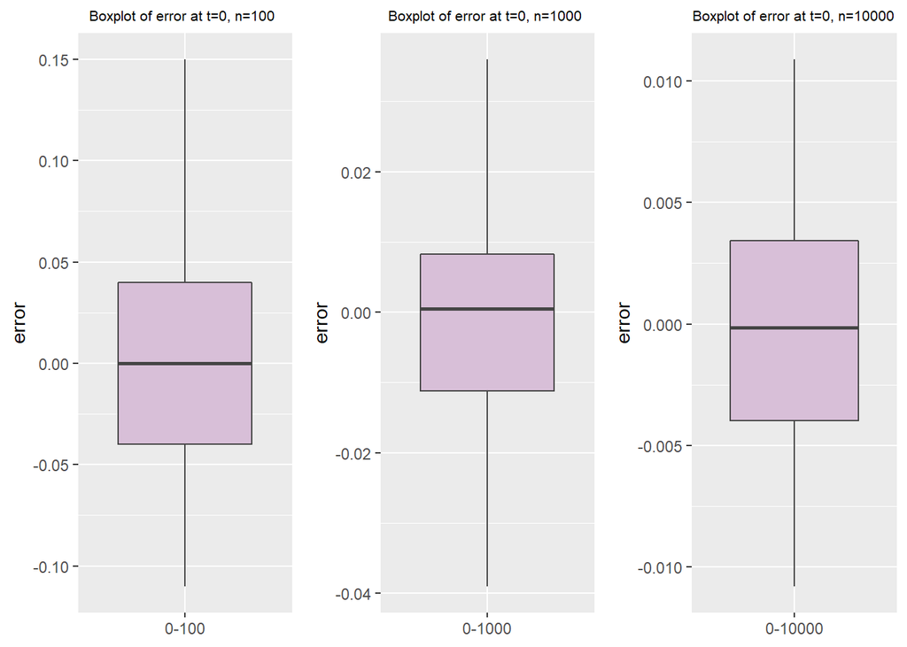

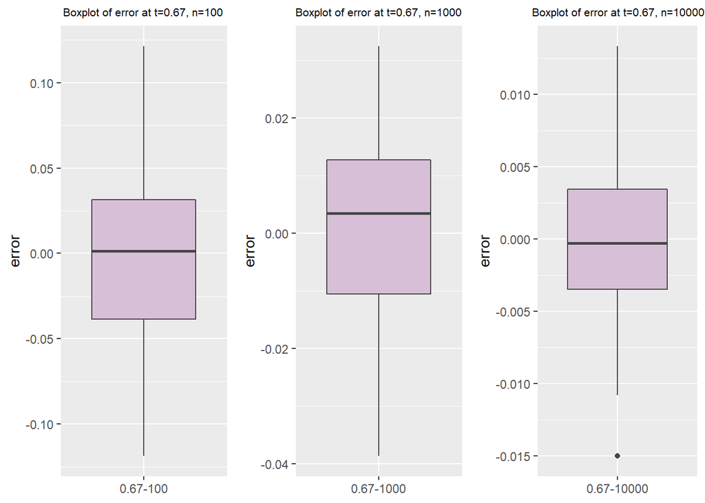

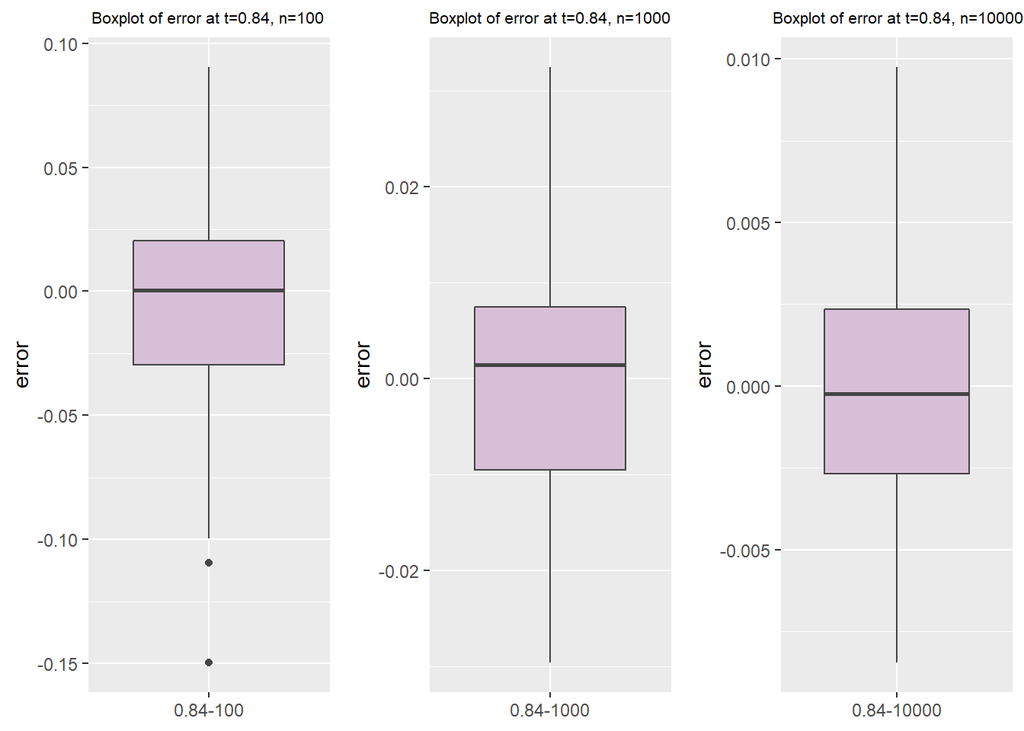

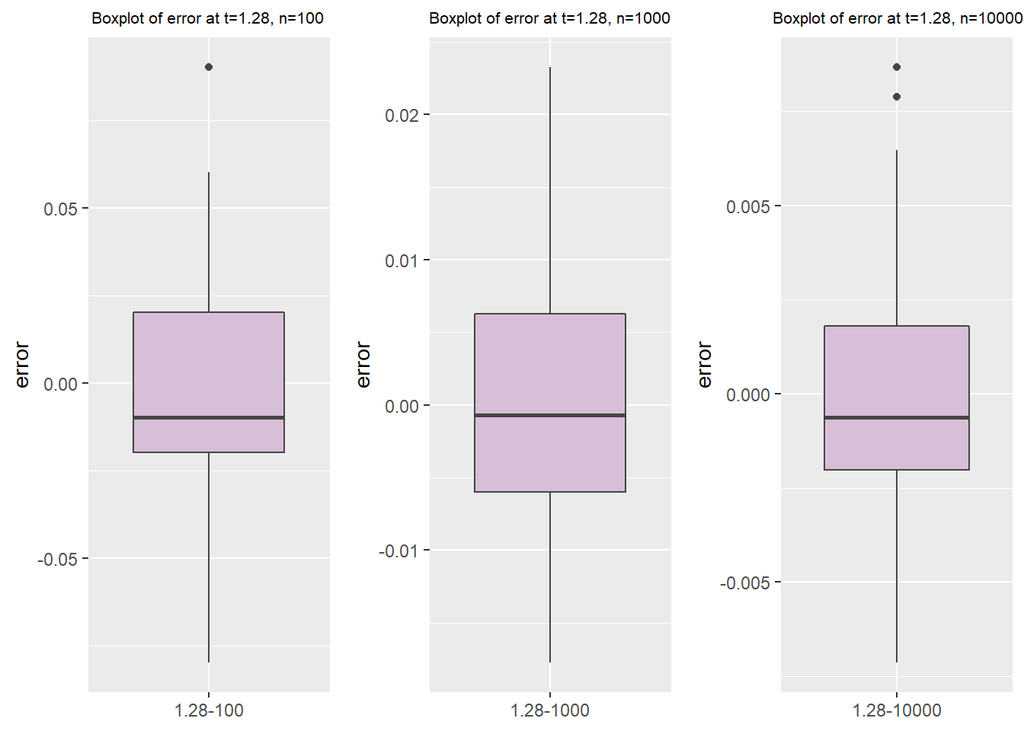

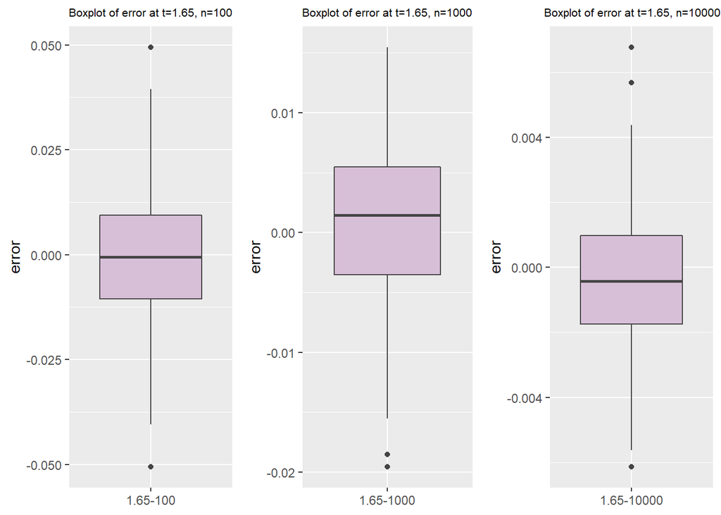

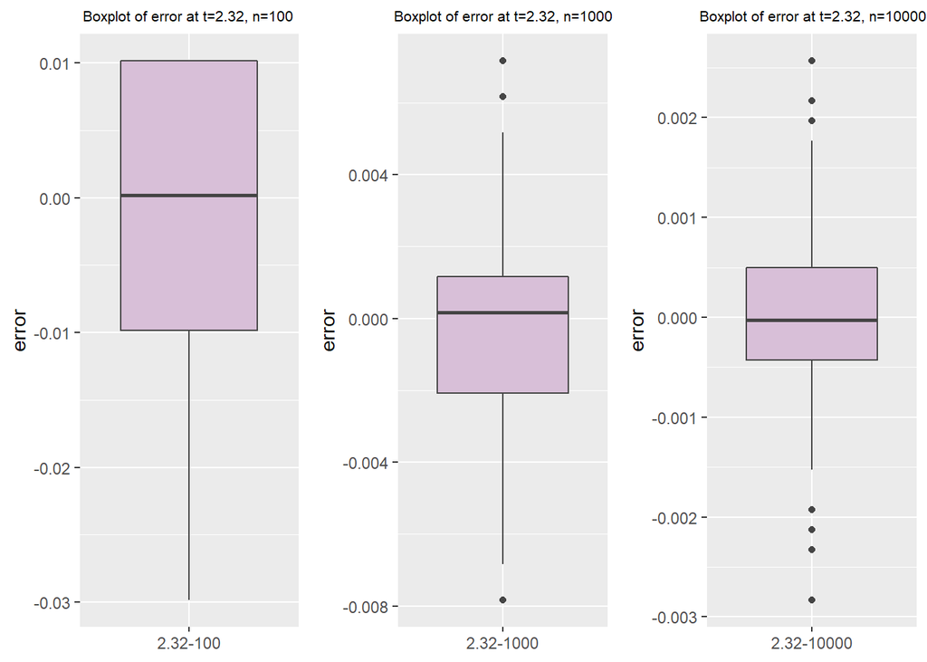

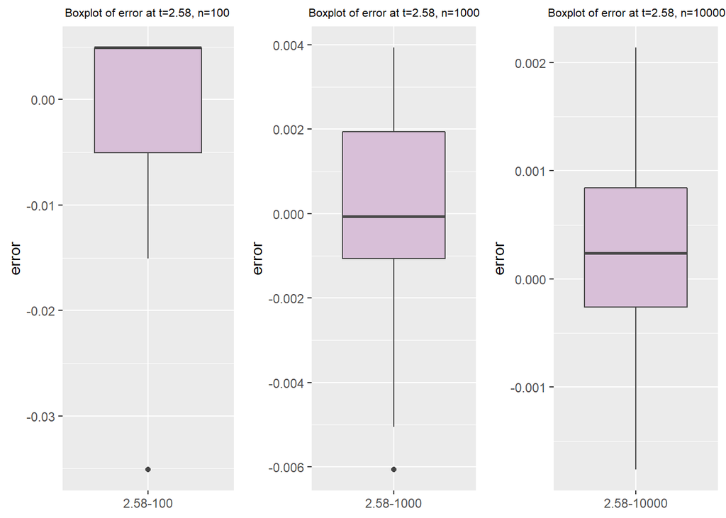

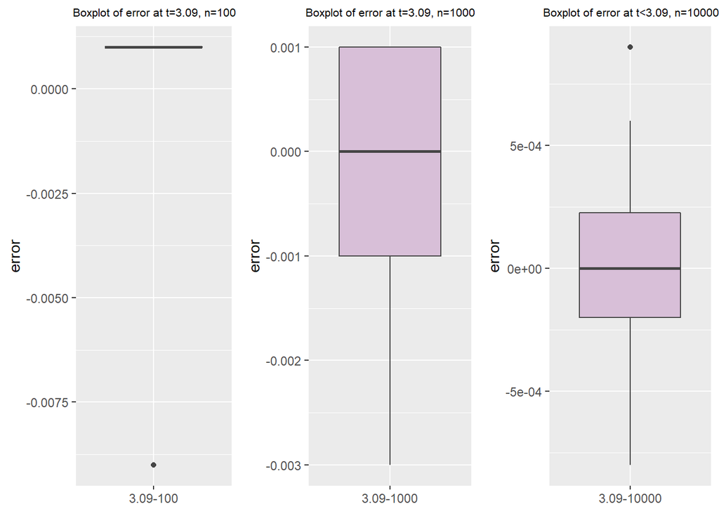

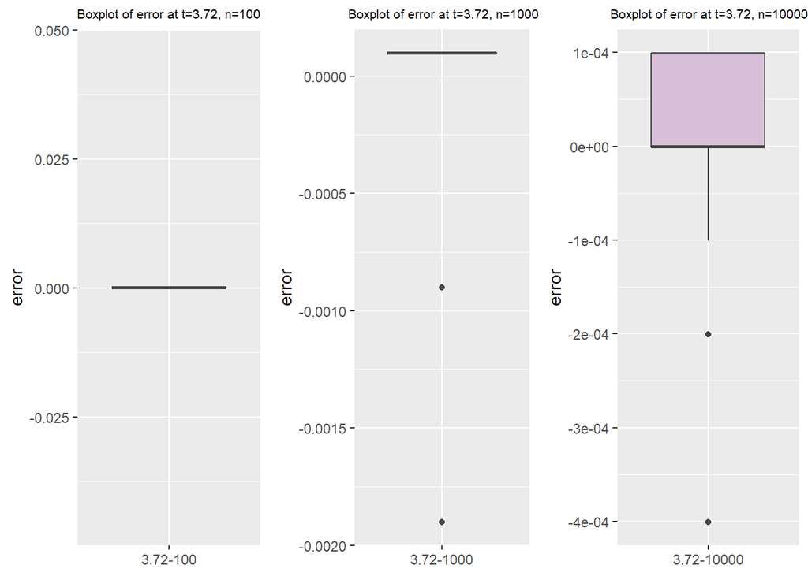

**Conclusion**

The error depends on both the number of sample and the extreme limitation.The more sample and the larger extreme limitation will bring the smaller error.